# Ridiculously Simple EDA in R

Exploratory Data Analysis plays a very important role in the entire Data Science Workflow. In fact, this takes most of the time of the Data science Workflow. There’s a nice quote (not sure who said it)

*“In Data Science, 80% of time spent prepare data, 20% of time spent complain about need for prepare data.”*

With R being the go-to language for a lot of Data Analysts, EDA requires an R Programmer to get a couple of packages from the infamous `tidyverse` world into their R code - even for the most basic EDA with some Bar plots and Histograms.

Recently, I came across this package `DataExplorer` that seems to be doing the entire EDA (at least, the typical basic EDA) with just one function `create_report()` that generates a nice presentable rendered Rmarkdown html document. That’s just a report automatically generated and what if you want the control of what you would like to perform EDA on, for which `DataExplorer` has got a couple of *plotting* functions for the same purpose.

### Let us begin our EDA by loading the library:

```r
library(DataExplorer)
```

### Loading input dataset into our R session for EDA:

```r
choco <- read.csv('C:/Users/SA31/Downloads/flavors_of_cacao.csv', header = T, stringsAsFactors = F)
```

### Variables

The very first thing that you’d want to do in your EDA is checking the dimension of the input dataset and the time of variables.

```r
plot_str(choco)
```

[output not shown]

### Man’s search for Missing Values

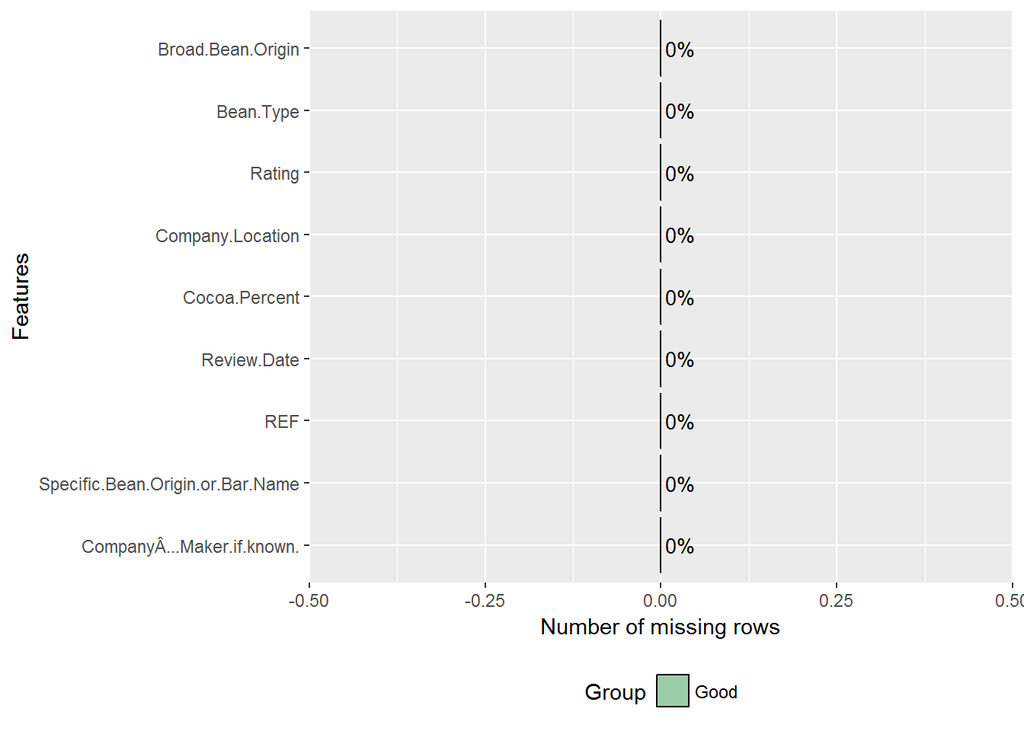

```r
plot_missing(choco)
```

And we are fortunate that there’s no missing value in this dataset.

### Histogram of Continuous Variables

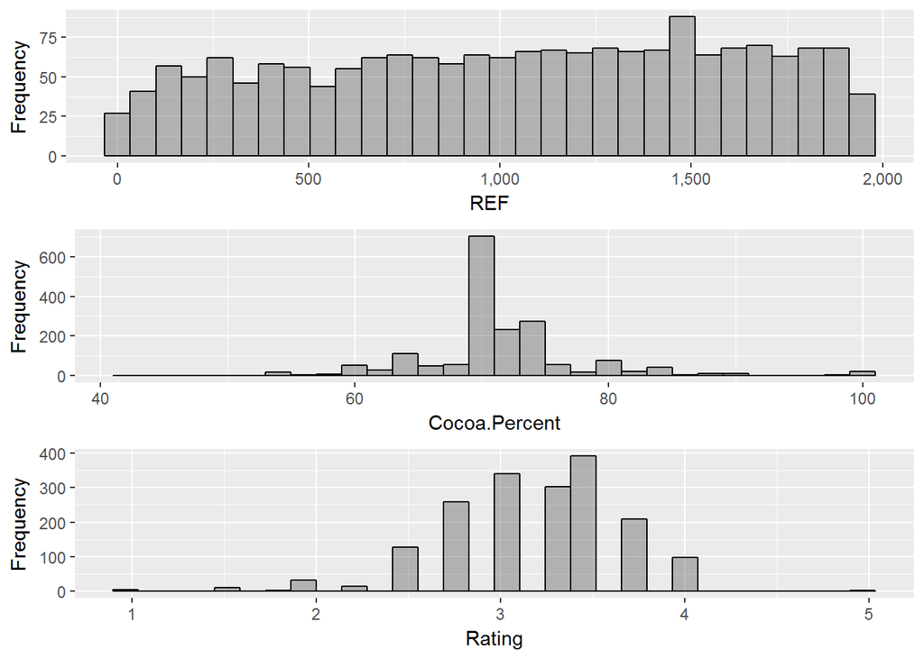

```r
plot_histogram(choco)
```

### Perhaps, you are a fan of Density plot

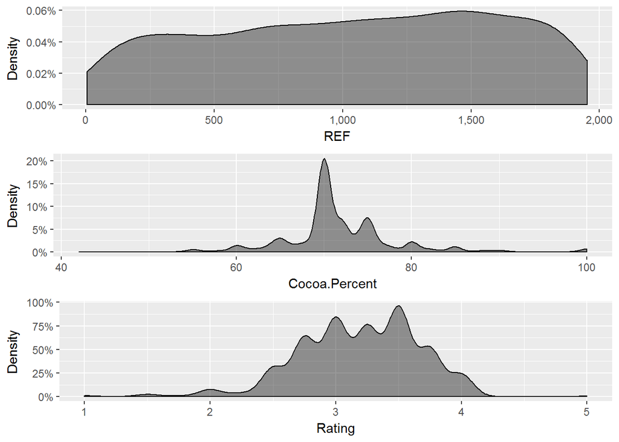

```r
plot_density(choco)
```

### Colorful Correlation Plot

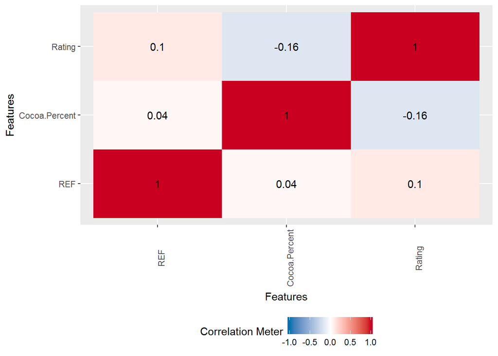

```r
plot_correlation(choco, type = 'continuous','Review.Date')
```

### Time for some Categorical Variables - Barplots!

```
## 4 columns ignored with more than 50 categories.
## CompanyÂ...Maker.if.known.: 416 categories
## Specific.Bean.Origin.or.Bar.Name: 1039 categories
## Company.Location: 60 categories
## Broad.Bean.Origin: 101 categories
```

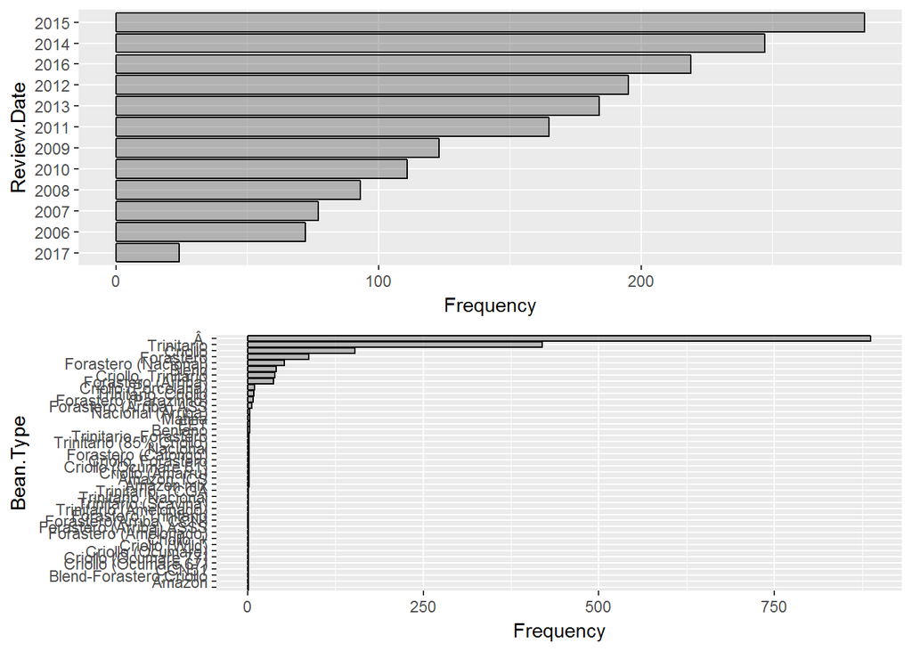

```r
plot_bar(choco)
```

And finally, if you have got only a couple of minutes (just like in the maggi noodles ad, 2 mins!) just keep it simple to use `create_report()`

```r
#create_report(choco) #comment this if you're not rendering this entire rmarkdown
```